# HM1

Lenin Valencia

2023-09-21

## Task

1. Tidying up and reporting central tendencies Using tidy and replicable principles, without making any manual changes or changing the file type convert the Country Ratings and Status, 1973-2016 (FINAL)_0.xlsx (Freedom House) data into country-year data. I downloaded this data for you, but this is how the data actually looks!
2. How many variables does the dataset contain? How many observations are there? Compute measures of central tendency and variability. Plot the distribution of both the PR and CL variable using a boxplot and histogram. Then try to make the same plot by year. Make sure to make your plots as professional as possible. Include a title and label the axes.

## Instruction

1. Submit all the files related to the assignment. These might include:
- Your Rmarkdown file
- Your markdown file (using output: github_document in Rmarkdown to get a homework readable on github)
- the data
- the RHistory and/or RProject
- the folder created when knitting the document
2. Include all your code (and the output) in the md file. Do not delete error messages and warnings. -Comment your code. Explain what you are trying to do. E.g. ``I’m using this function to…’’ -Make methodological decisions when necessary and rigorously defend these decisions. -Use headers to structure your assignments. Be clear about what questions you are answering. -Make your code tidy and replicable. Use defensive coding. -Avoid printing hundreds of lines of output in your md file. Use functions like head, limit the number of lines or subset your data. -Include a small amount of discussion for each question (i.e. interpret the graphs, the results). Make sure that you answer the question -(do not simply print numbers or graphs). -Other than in exceptional circumstances, there is no late submission. You need to submit what you have when the assignment is due.

```
##  [1] "1972"               "1973"               "1974"
##  [4] "1975"               "1976"               "1977"
##  [7] "1978"               "1979"               "1980"
## [10] "Jan.1981-Aug. 1982" "Aug.1982-Nov.1983"  "Nov.1983-Nov.1984"
## [13] "Nov.1984-Nov.1985"  "Nov.1985-Nov.1986"  "Nov.1986-Nov.1987"
## [16] "Nov.1987-Nov.1988"  "Nov.1988-Dec.1989"  "1990"
## [19] "1991"               "1992"               "1993"
## [22] "1994"               "1995"               "1996"
## [25] "1997"               "1998"               "1999"
## [28] "2000"               "2001"               "2002"
## [31] "2003"               "2004"               "2005"
## [34] "2006"               "2007"               "2008"
## [37] "2009"               "2010"               "2011"
## [40] "2012"               "2013"               "2014"
## [43] "2015"
```

[output not shown]

```
##  [1] "PR...2"   "PR...5"   "PR...8"   "PR...11"  "PR...14"  "PR...17"
##  [7] "PR...20"  "PR...23"  "PR...26"  "PR...29"  "PR...32"  "PR...35"
## [13] "PR...38"  "PR...41"  "PR...44"  "PR...47"  "PR...50"  "PR...53"
## [19] "PR...56"  "PR...59"  "PR...62"  "PR...65"  "PR...68"  "PR...71"
## [25] "PR...74"  "PR...77"  "PR...80"  "PR...83"  "PR...86"  "PR...89"
## [31] "PR...92"  "PR...95"  "PR...98"  "PR...101" "PR...104" "PR...107"
## [37] "PR...110" "PR...113" "PR...116" "PR...119" "PR...122" "PR...125"
## [43] "PR...128"
```

```
##  [1] "CL...3"   "CL...6"   "CL...9"   "CL...12"  "CL...15"  "CL...18"
##  [7] "CL...21"  "CL...24"  "CL...27"  "CL...30"  "CL...33"  "CL...36"
## [13] "CL...39"  "CL...42"  "CL...45"  "CL...48"  "CL...51"  "CL...54"
## [19] "CL...57"  "CL...60"  "CL...63"  "CL...66"  "CL...69"  "CL...72"
## [25] "CL...75"  "CL...78"  "CL...81"  "CL...84"  "CL...87"  "CL...90"
## [31] "CL...93"  "CL...96"  "CL...99"  "CL...102" "CL...105" "CL...108"
## [37] "CL...111" "CL...114" "CL...117" "CL...120" "CL...123" "CL...126"
## [43] "CL...129"
```

```
##  [1] "Status...4"   "Status...7"   "Status...10"  "Status...13"  "Status...16"
##  [6] "Status...19"  "Status...22"  "Status...25"  "Status...28"  "Status...31"
## [11] "Status...34"  "Status...37"  "Status...40"  "Status...43"  "Status...46"
## [16] "Status...49"  "Status...52"  "Status...55"  "Status...58"  "Status...61"
## [21] "Status...64"  "Status...67"  "Status...70"  "Status...73"  "Status...76"
## [26] "Status...79"  "Status...82"  "Status...85"  "Status...88"  "Status...91"
## [31] "Status...94"  "Status...97"  "Status...100" "Status...103" "Status...106"
## [36] "Status...109" "Status...112" "Status...115" "Status...118" "Status...121"
## [41] "Status...124" "Status...127" "Status...130"
```

```
##  [1] "1972"               "1973"               "1974"
##  [4] "1975"               "1976"               "1977"
##  [7] "1978"               "1979"               "1980"
## [10] "Jan.1981-Aug. 1982" "Aug.1982-Nov.1983"  "Nov.1983-Nov.1984"
## [13] "Nov.1984-Nov.1985"  "Nov.1985-Nov.1986"  "Nov.1986-Nov.1987"
## [16] "Nov.1987-Nov.1988"  "Nov.1988-Dec.1989"  "1990"
## [19] "1991"               "1992"               "1993"
## [22] "1994"               "1995"               "1996"
## [25] "1997"               "1998"               "1999"
## [28] "2000"               "2001"               "2002"
## [31] "2003"               "2004"               "2005"
## [34] "2006"               "2007"               "2008"
## [37] "2009"               "2010"               "2011"
## [40] "2012"               "2013"               "2014"
## [43] "2015"               "country"
```

```
## # A tibble: 8,858 × 5
##    country     year               PR    CL    Status
##    <chr>       <chr>              <chr> <chr> <chr>
##  1 Afghanistan 1972               4     5     PF
##  2 Afghanistan 1973               7     6     NF
##  3 Afghanistan 1974               7     6     NF
##  4 Afghanistan 1975               7     6     NF
##  5 Afghanistan 1976               7     6     NF
##  6 Afghanistan 1977               6     6     NF
##  7 Afghanistan 1978               7     7     NF
##  8 Afghanistan 1979               7     7     NF
##  9 Afghanistan 1980               7     7     NF
## 10 Afghanistan Jan.1981-Aug. 1982 7     7     NF
## # ℹ 8,848 more rows
```

[output not shown]

[output cut: 4444 more lines]

[output not shown]

```
## [1] "Found observations:"
```

```
## [1] 26574
```

```
## Mean PR= 3.761427
```

```
## Mean CL= 3.720406
```

```
## Median CL= 4
```

```
## Median PR= 4
```

```
## Mode PR= 1
```

```
## Mode CL= 1
```

```
## Variance CL= 3.804729
```

```
## Variance PR= 5.002466
```

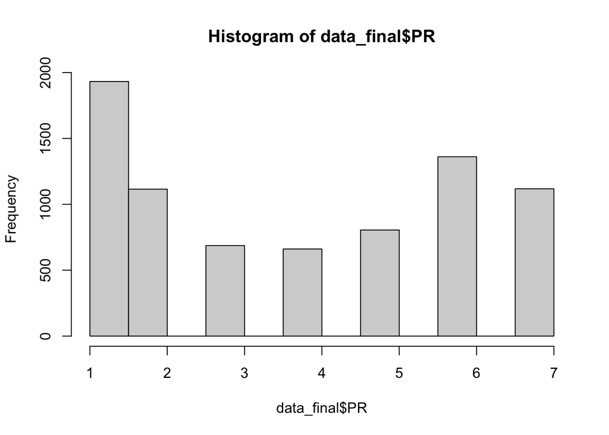

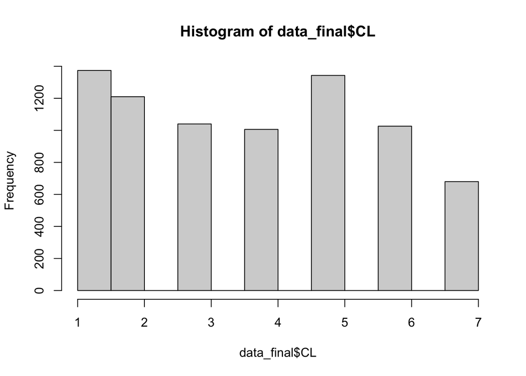

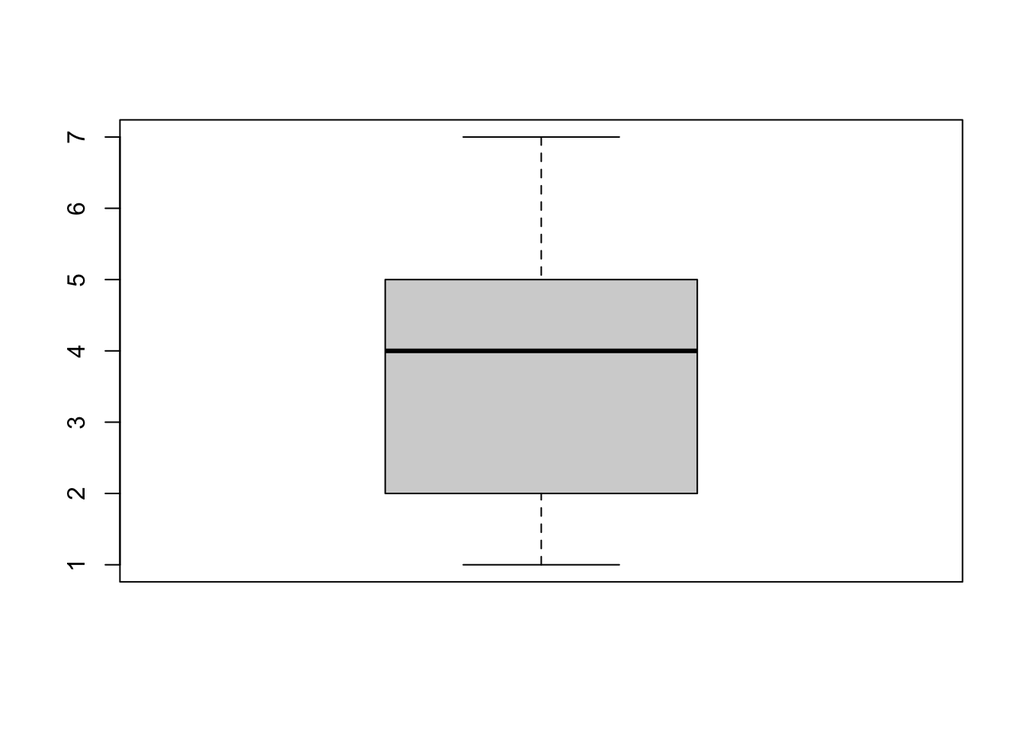

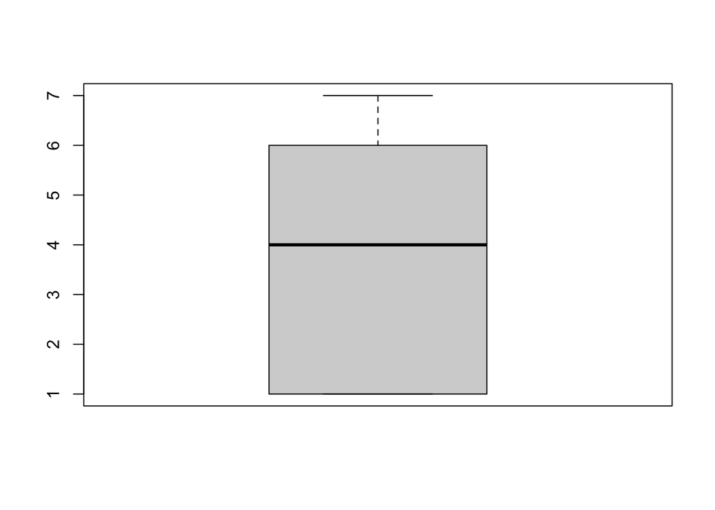

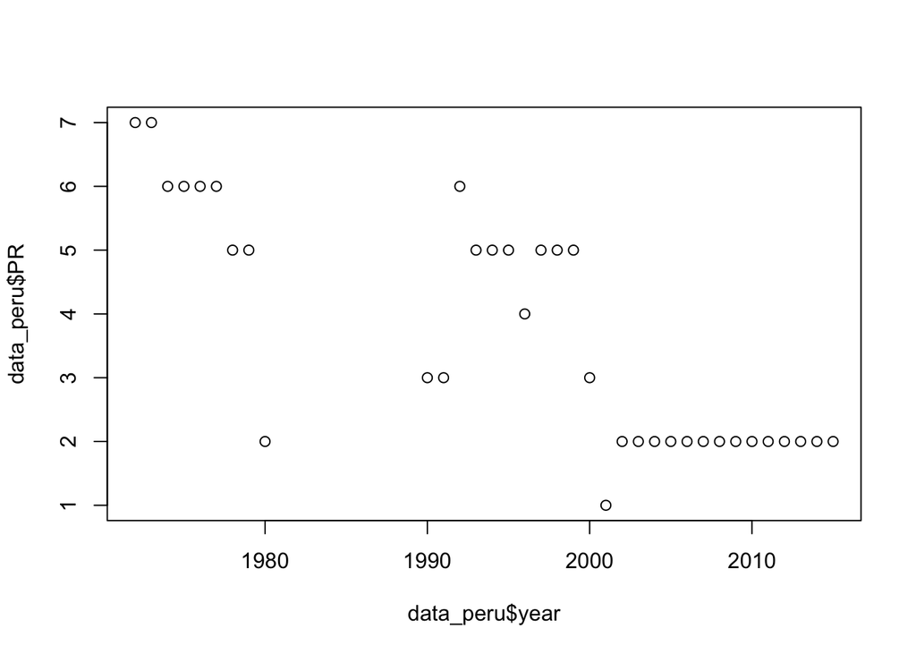